# StudentworkBookWeek10

Student

11/12/2019

## Week 10 Assignment DDO First Semester

In this assignment we will be looking at the content studied during the DDO course. We will focus especially on the meaning of certain queries. Some questions require only a SQL code, others will ask you to explain in plain English how the code works. The same explanation will go for the database relations.

> Being able to explain a set of code in simple wording is a good skill for IT engineers, regardless of their field of work. In your professional career, you will have to explain to a layman how a certain code is working. In most cases, this will be your manager or CEO, who has no IT experience. Commands like SELECT, WHERE and GROUP BY will not be understood and need additional explanation.

you are allowed to work in groups, making this workbook also ensures that you have all libraries for the individual test in week 12. (HINT make sure each member of the group can make the assignments.) Good Luck…

### Reading a DataBase

Looking at the ERD, shown in figure 1, we can see 6 different relations, describe all six in plain english going from 1 to many.

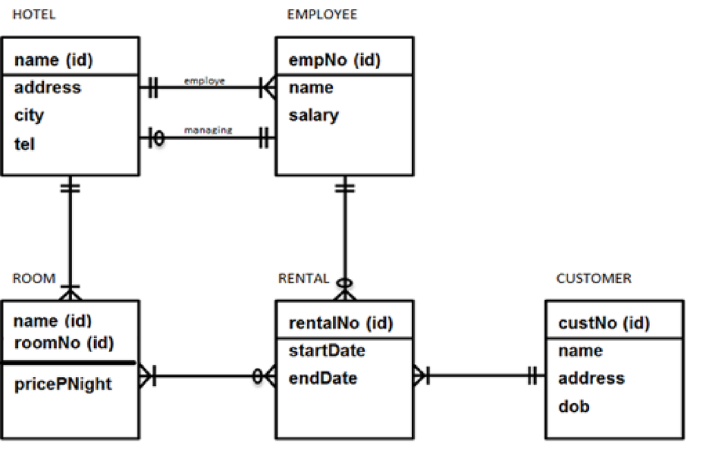

## SQL statements

Make an SQL query for the following questions. The desired result is printed below each question. Additionally in some question you need to provide an explanation of the code in plain English. Asume you have to discuss your result with a layman and he wants to understand what you have done.

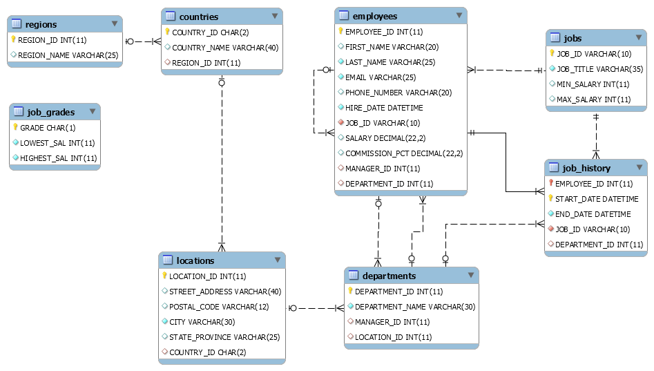

Make an SQL query for the following questions. The desired result is printed below each question.

1. The HR department needs a report to display the employee number, last name, salary, and salary increased by 15.5% for each employee with an employee ID below 110. Label the column New Salary.

```sql
SELECT EMPLOYEE_ID, LAST_NAME , SALARY, (SALARY + (SALARY*15.5/100)) AS "New salary"
/* we use select command to display the columns we want. We can also make a new column when doing math equations and give the column a name by using AS and "". */
FROM employees
/* we use from command to use the table that containes the columns we want.*/
WHERE EMPLOYEE_ID < 110;
/* we can use where command to choose a certin group of rows or a row depends in the information we have.*/
```

Displaying records 1 - 10

| employee_id | last_name | salary | New salary |
| --- | --- | --- | --- |
| 100 | King | 24000 | 27720 |
| 101 | Kochhar | 17000 | 19635 |
| 102 | De Haan | 17000 | 19635 |
| 103 | Hunold | 9000 | 10395 |
| 104 | Ernst | 6000 | 6930 |
| 105 | Austin | 4800 | 5544 |
| 106 | Pataballa | 4800 | 5544 |
| 107 | Lorentz | 4200 | 4851 |
| 108 | Greenberg | 12000 | 13860 |
| 109 | Faviet | 9000 | 10395 |

2. Find the highest, lowest, sum, and average salary of all employees. Label the columns Maximum, Minimum, Sum, and Average, respectively. Round your results to the nearest whole number.

```sql
SELECT ROUND(MAX(SALARY)) AS "Maximum", ROUND(MIN(SALARY)) AS "Minimum", ROUND(SUM(SALARY)) AS "Sum", ROUND(AVG(SALARY)) AS "Average"
/* We use ROUND() to Round results to the nearest whole number, We use MAX() to count the maximam salary, we use MIN() to get the minimum salary, we use SUM() to count the sum of the salary, and we use AVG() to count the average salary. */
/* We give the column a name by using AS and "". */
FROM employees
/* We use from command to use the table that containes the columns we want.*/
```

1 records

| Maximum | Minimum | Sum | Average |
| --- | --- | --- | --- |
| 24000 | 2100 | 691400 | 6462 |

3. Explain in plain english the following code.

```sql
SELECT job_id, MAX(salary) AS MaxSalary, MIN(salary) AS MinSalary,
SUM(salary) AS SumSalary, avg(salary) AS AvgSalary
/* We use MAX() to get the maximam salary, we use MIN() to get the minimum salary, we use SUM() to count the sum of the salary, and we use AVG() to count the average salary.We also use AS "" to give a column a new name*/
FROM employees
/* We use from command to use the table that containes the columns we want or the column that contines the information we want.*/
GROUP BY job_id;
/* We use GROUP BY command to get the results for each jop or to arrange identical data into groups.*/
/* This code is showing the job id column ,the maximum, the minimum, the sum and the average salary where minimum salary column name is MINSalary, maximum salary column name is MIXSalary and so on. All this information is from employees table and data is grouped by job id to show each job salary indivisualy.*/
```

Displaying records 1 - 10

| job_id | MaxSalary | MinSalary | SumSalary | AvgSalary |
| --- | --- | --- | --- | --- |
| AC_ACCOUNT | 8300 | 8300 | 8300 | 8300 |
| AC_MGR | 12000 | 12000 | 12000 | 12000 |
| AD_ASST | 4400 | 4400 | 4400 | 4400 |
| AD_PRES | 24000 | 24000 | 24000 | 24000 |
| AD_VP | 17000 | 17000 | 34000 | 17000 |
| FI_ACCOUNT | 9000 | 6900 | 39600 | 7920 |
| FI_MGR | 12000 | 12000 | 12000 | 12000 |
| HR_REP | 6500 | 6500 | 6500 | 6500 |
| IT_PROG | 9000 | 4200 | 28800 | 5760 |
| MK_MAN | 13000 | 13000 | 13000 | 13000 |

D. Write a query to display the number of employees with the same job.

```sql
SELECT JOB_ID, COUNT(EMPLOYEE_ID) AS "total_number"
FROM employees
GROUP BY JOB_ID;
```

Displaying records 1 - 10

| job_id | total_number |
| --- | --- |
| AC_ACCOUNT | 1 |
| AC_MGR | 1 |
| AD_ASST | 1 |
| AD_PRES | 1 |
| AD_VP | 2 |
| FI_ACCOUNT | 5 |
| FI_MGR | 1 |
| HR_REP | 1 |
| IT_PROG | 5 |
| MK_MAN | 1 |

E. Determine the number of managers without listing them. Label the column Number of Managers. Hint: Use the MANAGER_ID column to determine the number of managers.

```sql
SELECT COUNT(DISTINCT MANAGER_ID) AS "Number Of Managers"
FROM employees;
/* we use from command to use the table that containes the columns we want.*/
```

1 records

| Number Of Managers |
| --- |
| 19 |

F. Write a query to display the names (first_name, last_name, Hire_date, Job_id) using alias name “First Name”, “Last Name”, “Hired”, “Job” for all employees who’s first name starts with an “A”

```sql
SELECT FIRST_NAME AS "First Name", LAST_NAME AS "Last Name", HIRE_DATE AS "Hired", JOB_ID AS "Job"
FROM employees
WHERE FIRST_NAME LIKE 'A%';
```

Displaying records 1 - 10

| First Name | Last Name | Hired | Job |
| --- | --- | --- | --- |
| Alexander | Hunold | 1987-06-20 | IT_PROG |
| Alexander | Khoo | 1987-07-02 | PU_CLERK |
| Adam | Fripp | 1987-07-08 | ST_MAN |
| Alberto | Errazuriz | 1987-08-03 | SA_MAN |
| Allan | McEwen | 1987-08-14 | SA_REP |
| Amit | Banda | 1987-08-23 | SA_REP |
| Alyssa | Hutton | 1987-08-31 | SA_REP |
| Alexis | Bull | 1987-09-10 | SH_CLERK |
| Anthony | Cabrio | 1987-09-12 | SH_CLERK |
| Alana | Walsh | 1987-09-21 | SH_CLERK |

G. Explain the following code in plain English

```sql
SELECT manager_id, MIN(salary) AS MinSalary
/*We use SELECT command to display the columns we want which ares manger_id and minimum salary.  we use MIN() to get the minimum salary and AS "" to give it a new name*/
FROM employees
/* we use from command to use the table that containes the columns we want or the information. In this situation we need managers informations which are locatied in employees table*/
GROUP BY manager_id
/* we use group by command to arrange identical data into groups. Here we want to group by mangers ID's or to arrange identical managers id's into groups. */
HAVING MIN(salary)> 6000
/* We use HAVING command to  specifie a condition. Here we are asking for the data where the minimum salary is bigger than 6000. */
ORDER BY  MinSalary DESC
/* We use ORDER BY to arrange data either in ascending or descindin. Here we ask for data to be aranged in descinding order depinding in the minimum salary.*/
/* This code is showing Managers ID's and there minimum salary where the minimum salary is higher than 6000. Data is being arranged in the descinding order of minimum salary*/
```

9 records

| manager_id | MinSalary |
| --- | --- |
| 0 | 24000 |
| 102 | 9000 |
| 205 | 8300 |
| 145 | 7000 |
| 146 | 7000 |
| 108 | 6900 |
| 147 | 6200 |
| 149 | 6200 |
| 148 | 6100 |

H. Explain the following code in plain English, how could this chunk be improved using INNER JOIN?

```sql
SELECT e.last_name, e.job_id, e.department_id, d.depart_name
/*We use SELECT command to display the columns we want which are last name, job id , department id and department name. Before each of the columns name there is a letter and a dot which determans from where did we get this information. Where e. means we get it from employees table and d. means from department table. */
FROM employees e, departments d, locations l
/*Before each of the tables there is a letter and a dot which determans from where did we get this information. Where e. means we get it from employees table , d. means from department table and l. means from the loction table. */
WHERE e.department_id = d.department_id
AND d.location_id = l.location_id
AND LOWER(l.city) = 'toronto';
/*We use WHERE to only affect rows that meet specified criteria. Here we are saying that the column department ID from table employees is the same table from table department. And the same thing goes for location ID column.
we also say that we want a specific condtion from the column city which is located in loction table, this condtion is that the data from the column city is for toranto. */
/* This code ask to show last name, jop id, department id and department name columns. The letters and the dots shortcuts are used to spcifiy the columns loctions and to spcifiey the same data for the same column in a diffrent table. It shows the mentioned columns for touranto city.*/

/* This chunk colud be improvied if we wrote it like this:
SELECT e.last_name, e.job_id, e.department_id, d.depart_name
FROM employees AS e
INNER JOIN departments as d and locations as l
ON e.department_id = d.department_id and d.location_id = l.location_id
WHERE LOWER(l.city) = 'toronto'; */
```

2 records

| last_name | job_id | department_id | depart_name |
| --- | --- | --- | --- |
| Hartstein | MK_MAN | 20 | Marketing |
| Fay | MK_REP | 20 | Marketing |

I. The HR department needs to find the names, salary and hire dates for all employees who have a higher salary than their managers, along with their managersâ names and hire dates and salary.

```sql
  SELECT w.last_name as "employee",
       w.hire_date as "Hired_Em",
       w.salary as "Salary_Em",
       m.last_name as "Manager",
       m.hire_date  as "Hired_Ma",
       m.salary as "Salary_Ma"
FROM employees w,
     employees m
WHERE w.manager_id = m.employee_id
  AND w.salary > m.salary;
```

2 records

| employee | Hired_Em | Salary_Em | Manager | Hired_Ma | Salary_Ma |
| --- | --- | --- | --- | --- | --- |
| Ozer | 1987-08-24 | 11500 | Cambrault | 1987-08-04 | 11000 |
| Abel | 1987-08-30 | 11000 | Zlotkey | 1987-08-05 | 10500 |

J. Explain the following code in plain English

```sql
SELECT last_name, department_id, job_id
/*We use SELECT command to display the columns we want which are last name, department and job id.*/
FROM employees
/*we use FROM to select the Table name that contianes the data we want to use.*/
WHERE department_id IN (
/* we usse where to give a spcified condition for a row. we use IN command which allow us to specify multiple values in a WHERE clause. In this case we are saying that department id in employee table is the same in department table*/
  SELECT department_id
  FROM departments
  WHERE location_id = 1700);
  /* we are spcifieng loction id or department to 1700 by using WHERE command and loction id to equal 1700.*/

  /* in this code we are asking to show the last employee name, the department id and the job id in the loction 1700. */
```

Displaying records 1 - 10

| last_name | department_id | job_id |
| --- | --- | --- |
| King | 90 | AD_PRES |
| Kochhar | 90 | AD_VP |
| De Haan | 90 | AD_VP |
| Greenberg | 100 | FI_MGR |
| Faviet | 100 | FI_ACCOUNT |
| Chen | 100 | FI_ACCOUNT |
| Sciarra | 100 | FI_ACCOUNT |
| Urman | 100 | FI_ACCOUNT |
| Popp | 100 | FI_ACCOUNT |
| Raphaely | 30 | PU_MAN |

K. Create a report for HR that displays the last name and salary of every employee who reports to King.

```sql
SELECT last_name, salary
From employees
WHERE manager_id in (
               select employee_id
               from employees
               where last_name='King');
```

Displaying records 1 - 10

| last_name | salary |
| --- | --- |
| Kochhar | 17000 |
| De Haan | 17000 |
| Raphaely | 11000 |
| Weiss | 8000 |
| Fripp | 8200 |
| Kaufling | 7900 |
| Vollman | 6500 |
| Mourgos | 5800 |
| Russell | 14000 |
| Partners | 13500 |

## BONUS

As with every bonus this is a more complext challange allowing to show more skills. It is still part of the whole assignment and as such taken into account with the formative indication.

```sql
Select department_id,
       COUNT(distinct employee_ID) as Employees,
       MIN(Salary) as min,
       MAX(Salary) as max
  From employees
 Group by department_ID;
```

Displaying records 1 - 10

| department_id | Employees | min | max |
| --- | --- | --- | --- |
| 0 | 1 | 7000 | 7000 |
| 10 | 1 | 4400 | 4400 |
| 20 | 2 | 6000 | 13000 |
| 30 | 6 | 2500 | 11000 |
| 40 | 1 | 6500 | 6500 |
| 50 | 45 | 2100 | 8200 |
| 60 | 5 | 4200 | 9000 |
| 70 | 1 | 10000 | 10000 |
| 80 | 34 | 6100 | 14000 |
| 90 | 3 | 17000 | 24000 |

```r
ggplot(department_ID, aes(x = min, y = max , color = department_id)) +
  geom_point()
```

[output not shown]

```
## Error in ggplot(department_ID, aes(x = min, y = max, color = department_id)): object 'department_ID' not found
```